# Adult Foreleg Length - Heritability estimate and GWAS Conditional Analysis

Caelinn James

02 April 2021

**Written for R 4.0.2, last updated 31/07/21**

This is a follow on from the adult foreleg length heritability estimate and GWAS script. The analysis identified peaks on chromosome 19 and 16. Here, we fit SNPs s74894.1 and s22142.1 to see how much of the variation they accounts for and to see if there are any close significant SNPs that are obscured by the original peaks.

### Load packages

```r
library(data.table)
library(stringr)
library(splitstackshape)
library(qqman)
```

### Preparing files

> #!/bin/sh  
> #$ -cwd  
> #$ -l h_rt=1:00:00  
> #$ -pe sharedmem 1  
> #$ -l h_vmem=100G  
> #$ -M s1944058@sms.ed.ac.uk  
> #$ -m baes

> . /etc/profile.d/modules.sh

> module load igmm/apps/plink/1.90b4 module load igmm/apps/R/3.5.1

> plink –bfile 50K/AdultForeLeg50K –sheep –not-chr 0,X –exclude-snps s74894.1, s22142.1 –make-bed –out 50K/Conditional_50K_Geno  
> plink –bfile HD/AdultForeLegHD –sheep –not-chr X –exclude-snps s74894.1, s22142.1 –make-bed –out HD/Conditional_HD_Geno

> plink –bfile 50K/AdultForeLeg50K –sheep –snps s74894.1, s22142.1 –keep AdultForeLegPhenotypes.txt –recodeA –out AdultMetaSNP cut -d ’ ’ -f 3-6 –complement AdultMetaSNP.raw > AdultMetaSNP.txt  
> sed ‘1d’ AdultMetaSNP.txt > AdultMetaSNP2.txt

> sort -k 2,2 AdultForeLegQAssoc.txt > Assoc1.txt  
> sort -k 2,2 AdultMetaSNP2.txt > Assoc2.txt

> R  
> Assoc1 = read.table(“Assoc1.txt”)  
> Assoc2 = read.table(“Assoc2.txt”)  
> Assoc3 = merge(Assoc1,Assoc2,by=c(“V1”,“V2”)) write.table(Assoc3, “Assoc3.txt”,row.names=FALSE,col.names=FALSE,quote=FALSE) q()

> sort -k 2,2 AdultForeLegAssoc.txt > Assoc.txt  
> sort -k 2,2 Assoc3.txt > QAssoc.txt

## Heritability Estimates

### 50K

> #!/bin/sh  
> #$ -cwd  
> #$ -l h_rt=1:00:00  
> #$ -pe sharedmem 1  
> #$ -l h_vmem=100G  
> #$ -M s1944058@sms.ed.ac.uk  
> #$ -m baes  
> . /etc/profile.d/modules.sh

> module load igmm/apps/dissect/1.15.2c  
> module load igmm/apps/plink/1.90b4

> mpirun -np 8 dissect.mpich --reml --bfile 50K/Conditional_50K_Geno --pheno AdultForelegPhenotypes.txt --pheno-col 2 --blue --covar Assoc.txt --qcovar QAssoc.txt --random-effects ForelegRandom.txt --random-effects-cols 1 2 3 --out 50K/AdultForeLeg_50K_Conditional_H2

> if [[ -f 50K/AdultForeLeg_50K_Conditional_H2.badsnps ]]  
> then  
> plink --bfile 50K/Conditional_50K_Geno --sheep --exclude 50K/AdultForeLeg_50K_Conditional_H2.badsnps --make-bed --out 50K/AdultForeLeg_50K_Conditional_H2

> mpirun -np 8 dissect.mpich --reml --bfile 50K/AdultForeLeg_50K_Conditional_H2 --pheno AdultForelegPhenotypes.txt --pheno-col 2 --blue --covar Assoc.txt --qcovar QAssoc.txt --random-effects ForelegRandom.txt --random-effects-cols 1 2 3 --out 50K/AdultForeLeg_50K_Conditional_H2  
> fi

```r
FixedEffects_50K
```

```
##                NAME        BETA        STD
## 1               Sex -6.99697000 0.28486100
## 2        Population  0.00397268 0.00125837
## 3      Age at death  0.16602100 0.02938200
## 4 s74894.1 (Chr 19) -3.81410000 0.51268200
## 5  s22142.1 (Chr16) -2.35902000 0.34637800
```

```r
RandomEffects_50K
```

```
##                            NAME     BETA       STD
## 1:                  Var(GRM_p1)  9.06281   1.22299
## 2:              Var(CapYear_p1)    15.47    4.0196
## 3:                   Var(ID_p1)  7.55482  0.840221
## 4:                    Var(E_p1)  7.83319  0.232882
## 5: Var(GRM_p1)/Var(Phenotype_1) 0.227019 0.0351598
```

### HD

> #!/bin/sh  
> #$ -cwd  
> #$ -l h_rt=1:00:00  
> #$ -pe sharedmem 1  
> #$ -l h_vmem=100G  
> #$ -M s1944058@sms.ed.ac.uk  
> #$ -m baes  
> . /etc/profile.d/modules.sh

> module load igmm/apps/dissect/1.15.2c  
> module load igmm/apps/plink/1.90b4

> mpirun -np 8 dissect.mpich --reml --bfile HD/Conditional_HD_Geno --pheno AdultForelegPhenotypes.txt --pheno-col 2 --blue --covar Assoc.txt --qcovar QAssoc.txt --random-effects ForelegRandom.txt --random-effects-cols 1 2 3 --out HD/AdultForeLeg_HD_Conditional_H2

> if [[ -f HD/AdultForeLeg_HD_Conditional_H2.badsnps ]]  
> then  
> plink --bfile HD/Conditional_HD_Geno --sheep --exclude HD/AdultForeLeg_HD_Conditional_H2.badsnps --make-bed --out HD/AdultForeLeg_HD_Conditional_H2

> mpirun -np 8 dissect.mpich --reml --bfile HD/AdultForeLeg_HD_Conditional_H2 --pheno AdultForelegPhenotypes.txt --pheno-col 2 --blue --covar Assoc.txt --qcovar QAssoc.txt --random-effects ForelegRandom.txt --random-effects-cols 1 2 3 --out HD/AdultForeLeg_HD_Conditional_H2  
> fi

```r
FixedEffects_HD
```

```
##                NAME        BETA        STD
## 1               Sex -6.99544000 0.28371700
## 2        Population  0.00400568 0.00125224
## 3      Age at death  0.17049200 0.02947180
## 4 s74894.1 (Chr 19) -3.83509000 0.51651700
## 5  s22142.1 (Chr16) -2.32672000 0.35433800
```

```r
RandomEffects_HD
```

```
##                            NAME    BETA       STD
## 1:                  Var(GRM_p1) 9.47803   1.23808
## 2:              Var(CapYear_p1) 15.6753   4.07428
## 3:                   Var(ID_p1)   7.079  0.832226
## 4:                    Var(E_p1) 7.83378  0.232863
## 5: Var(GRM_p1)/Var(Phenotype_1) 0.23656 0.0359665
```

### GWAS

> #!/bin/sh  
> #$ -cwd  
> #$ -l h_rt=2:00:00  
> #$ -pe sharedmem 1  
> #$ -l h_vmem=200G  
> #$ -t 1-26  
> #$ -tc 5  
> #$ -M s1944058@sms.ed.ac.uk  
> #$ -m baes  
> . /etc/profile.d/modules.sh

> module load igmm/apps/dissect/1.15.2c  
> module load igmm/apps/plink/1.90b4

> i=$_TASK_ID

> plink --bfile 50K/Conditional_50K_Geno --sheep --not-chr ${i},X --keep AdultForelegPhenotypes.txt --make-bed --out 50K/NoChr${i}

> mpirun -np 8 dissect.mpich --make-grm --bfile 50K/NoChr${i} --out 50K/NoChr${i}_GRM

> echo "50K/Chr${i} 50K/NoChr${i}_GRM" > 50K/GWAS_GRM${i}.txt

> plink --bfile 50K/Conditional_50K_Geno --sheep --chr ${i} --keep AdultForelegPhenotypes.txt --make-bed --out 50K/Chr${i}

> if [[ -f 50K/NoChr${i}_GRM.badsnps ]]  
> then  
> plink --bfile 50K/NoChr${i} --sheep --exclude 50K/NoChr${i}_GRM.badsnps --make-bed --out 50K/NoChr${i}_2

> mpirun -np 8 dissect.mpich --make-grm --bfile 50K/NoChr${i}_2 --out 50K/NoChr${i}_GRM

> fi

> mpirun -np 8 dissect.mpich --gwas --bfile-grm-list 50K/GWAS_GRM${i}.txt --pheno AdultForelegPhenotypes.txt --pheno-col 2 --covar Assoc.txt --qcovar QAssoc.txt --random-effects ForelegRandom.txt --random-effects-cols 1 2 3 --out 50K/AdultForeLeg_50K_GWAS_Conditional_Chr${i}

> if [[ -f 50K/AdultForeLeg_50K_GWAS_Conditional_Chr${i}.badsnps ]]  
> then  
> plink --bfile 50K/Chr${i} --sheep --exclude 50K/AdultForeLeg_50K_GWAS_Conditional_Chr${i}.badsnps --make-bed --out 50K/Chr${i}_2

> echo "50K/Chr${i}_2 50K/NoChr${i}_GRM" > 50K/GWAS_GRM${i}.txt

> mpirun -np 8 dissect.mpich --gwas --bfile-grm-list 50K/GWAS_GRM${i}.txt --pheno AdultForelegPhenotypes.txt --pheno-col 2 --covar Assoc.txt --qcovar QAssoc.txt --random-effects ForelegRandom.txt --random-effects-cols 1 2 3 --out 50K/AdultForeLeg_50K_GWAS_Conditional_Chr${i}  
> fi

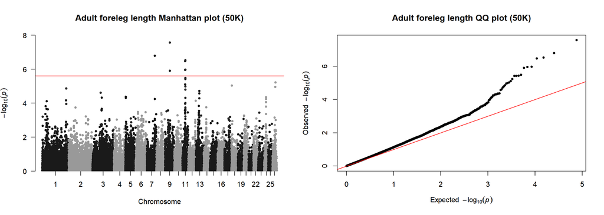

```r
files = list.files(pattern="AdultForeLeg_50K_GWAS_Conditional_Chr",recursive=TRUE)

SNPresults = do.call(rbind, lapply(files, function(x) read.table(x,header=T)))
SNPresults$Effect <- SNPresults$STDEV*SNPresults$STDEV*SNPresults$BETA*SNPresults$BETA

bimFile <- read.table("C:/Users/s1944058/Documents/Sheep/50KSNP/Plates_1to87_QC3.bim",header=F)

GWAS50KResults <- merge(bimFile,SNPresults[,c("SNP","PV","Effect"),],by.x="V2",by.y="SNP",all.x=FALSE,all.y=TRUE)
colnames(GWAS50KResults) <- c("SNP","Chr","V3","Pos","Ref","Minor","PV","Effect")
GWAS50KResults$Chr <- as.numeric(GWAS50KResults$Chr)
par(mfrow=c(1,2))
manhattan(GWAS50KResults,chr="Chr",bp="Pos",p="PV",snp="SNP", main = "Adult foreleg length Manhattan plot (50K)", genomewideline = -log10(0.05/20082),suggestiveline = FALSE)
qq(GWAS50KResults$PV,main="Adult foreleg length QQ plot (50K)")
```

```r
SNPs <- GWAS50KResults[which(GWAS50KResults$PV < (0.05/20082) ),c("Chr","Pos","SNP","PV","Effect")]
SNPs[order(SNPs$PV),]
```

```
##       Chr      Pos              SNP         PV    Effect
## 34108   9 50463148         s50107.1 2.7161e-08 0.3002218
## 33891   7 84579439         s48811.1 1.6141e-07 0.1230971
## 4755   11 30811134 OAR11_32693010.1 3.0271e-07 0.2474306
## 4744   11 29828994 OAR11_31486316.1 3.4150e-07 0.1825409
## 4764   11 31380176 OAR11_33427461.1 1.0700e-06 0.2312186
## 37528  11 29248974         s72261.1 1.0995e-06 0.2233924
## 33918   9 50472159         s49039.1 1.2378e-06 0.2338574
```

### Imputed SNP data

> #!/bin/sh  
> #$ -cwd  
> #$ -l h_rt=3:00:00  
> #$ -pe sharedmem 1  
> #$ -l h_vmem=200G  
> #$ -t 1-26  
> #$ -tc 5  
> #$ -M s1944058@sms.ed.ac.uk  
> #$ -m baes  
> . /etc/profile.d/modules.sh

> module load igmm/apps/dissect/1.15.2c  
> module load igmm/apps/plink/1.90b4

> i=$_TASK_ID

> plink --bfile HD/Conditional_HD_Geno --sheep --not-chr ${i},X --keep AdultForelegPhenotypes.txt --make-bed --out HD/NoChr${i}

> mpirun -np 8 dissect.mpich --make-grm --bfile HD/NoChr${i} --out HD/NoChr${i}_GRM

> echo "HD/Chr${i} HD/NoChr${i}_GRM" > HD/GWAS_GRM${i}.txt

> plink --bfile HD/Conditional_HD_Geno --sheep --chr ${i} --keep AdultForelegPhenotypes.txt --make-bed --out HD/Chr${i}

> if [[ -f HD/NoChr${i}_GRM.badsnps ]]  
> then  
> plink --bfile HD/NoChr${i} --sheep --exclude HD/NoChr${i}_GRM.badsnps --make-bed --out HD/NoChr${i}_2

> mpirun -np 8 dissect.mpich --make-grm --bfile HD/NoChr${i}_2 --out HD/NoChr${i}_GRM

> fi

> mpirun -np 8 dissect.mpich --gwas --bfile-grm-list HD/GWAS_GRM${i}.txt --pheno AdultForelegPhenotypes.txt --pheno-col 2 --covar Assoc.txt --qcovar QAssoc.txt --random-effects ForelegRandom.txt --random-effects-cols 1 2 3 --out HD/AdultForeLeg_HD_GWAS_Conditional_Chr${i}

> if [[ -f HD/AdultForeLeg_HD_GWAS_Conditional_Chr${i}.badsnps ]]  
> then  
> plink --bfile HD/Chr${i} --sheep --exclude HD/AdultForeLeg_HD_GWAS_Conditional_Chr${i}.badsnps --make-bed --out HD/Chr${i}_2

> echo "HD/Chr${i}_2 HD/NoChr${i}_GRM" > HD/GWAS_GRM${i}.txt

> mpirun -np 8 dissect.mpich --gwas --bfile-grm-list HD/GWAS_GRM${i}.txt --pheno AdultForelegPhenotypes.txt --pheno-col 2 --covar Assoc.txt --qcovar QAssoc.txt --random-effects ForelegRandom.txt --random-effects-cols 1 2 3 --out HD/AdultForeLeg_HD_GWAS_Conditional_Chr${i}  
> fi

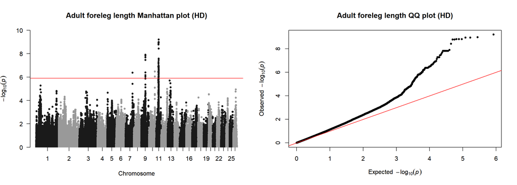

```r
files = list.files(pattern="AdultForeLeg_HD_GWAS_Conditional_Chr",recursive=TRUE)

SNPresults = do.call(rbind, lapply(files, function(x) read.table(x,header=T)))
SNPresults$Effect <- SNPresults$STDEV*SNPresults$STDEV*SNPresults$BETA*SNPresults$BETA

bimFile <- read.table("C:/Users/s1944058/Documents/Sheep/HDSNP/sheep_geno_imputed_oar31_17052020.bim",header=F)

GWASHDResults <- merge(bimFile,SNPresults[,c("SNP","PV","Effect"),],by.x="V2",by.y="SNP",all.x=FALSE,all.y=TRUE)
colnames(GWASHDResults) <- c("SNP","Chr","V3","Pos","Ref","Minor","PV","Effect")
GWASHDResults$Chr <- as.numeric(GWASHDResults$Chr)
par(mfrow=c(1,2))
manhattan(GWASHDResults,chr="Chr",bp="Pos",p="PV",snp="SNP", main = "Adult foreleg length Manhattan plot (HD)", genomewideline = -log10(0.05/39149),suggestiveline = FALSE)
qq(GWASHDResults$PV,main="Adult foreleg length QQ plot (HD)")
```

```r
SNPs <- GWASHDResults[which(GWASHDResults$PV < (0.05/39149) ),c("Chr","Pos","SNP","PV","Effect")]
SNPs[order(SNPs$PV),]
```

```
##        Chr      Pos                 SNP         PV    Effect
## 80026   11 30635038 oar3_OAR11_30635038 6.2881e-10 0.3165930
## 80044   11 30749205 oar3_OAR11_30749205 1.0319e-09 0.3098392
## 79908   11 29896204 oar3_OAR11_29896204 1.1202e-09 0.3159609
## 80068   11 30832740 oar3_OAR11_30832740 1.1382e-09 0.3144249
## 79906   11 29893020 oar3_OAR11_29893020 1.5022e-09 0.3111453
## 79920   11 29987623 oar3_OAR11_29987623 1.5314e-09 0.3109992
## 79921   11 29995815 oar3_OAR11_29995815 1.5314e-09 0.3109992
## 79904   11 29881030 oar3_OAR11_29881030 1.6385e-09 0.3097390
## 79905   11 29884883 oar3_OAR11_29884883 1.6385e-09 0.3097390
## 80059   11 30789963 oar3_OAR11_30789963 3.7187e-09 0.2900630
## 391419   9 50469115  oar3_OAR9_50469115 1.2426e-08 0.3127460
## 391408   9 50419097  oar3_OAR9_50419097 1.5119e-08 0.3095910
## 391410   9 50428124  oar3_OAR9_50428124 1.5119e-08 0.3095910
## 391411   9 50439231  oar3_OAR9_50439231 1.5119e-08 0.3095910
```

[output cut: 65 more lines]

## **FINAL RESULTS**

### 50K

```r
FixedEffects_50K[c(4,5),]
```

```
##                NAME     BETA      STD
## 4 s74894.1 (Chr 19) -3.81410 0.512682
## 5  s22142.1 (Chr16) -2.35902 0.346378
```

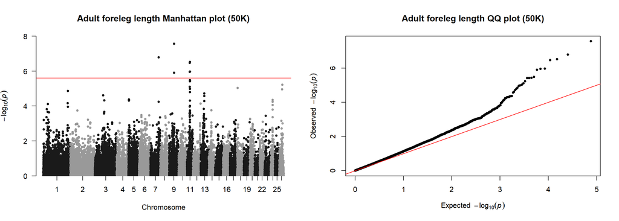

```r
par(mfrow=c(1,2))
manhattan(GWAS50KResults,chr="Chr",bp="Pos",p="PV",snp="SNP", main = "Adult foreleg length Manhattan plot (50K)", genomewideline = -log10(0.05/20082),suggestiveline = FALSE)
qq(GWAS50KResults$PV,main="Adult foreleg length QQ plot (50K)")
```

### HD

```r
FixedEffects_HD[c(4,5),]
```

```
##                NAME     BETA      STD
## 4 s74894.1 (Chr 19) -3.83509 0.516517
## 5  s22142.1 (Chr16) -2.32672 0.354338
```

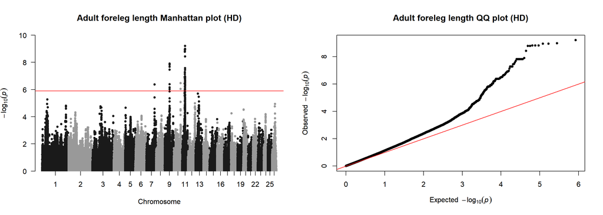

```r
par(mfrow=c(1,2))
manhattan(GWASHDResults,chr="Chr",bp="Pos",p="PV",snp="SNP", main = "Adult foreleg length Manhattan plot (HD)", genomewideline = -log10(0.05/39149),suggestiveline = FALSE)
qq(GWASHDResults$PV,main="Adult foreleg length QQ plot (HD)")
```